# Python İle Veri Bilimi Final Projesi

## Bilgisayar Mühendisliği(i.ö)

# İş Bankası 2015-2023 Arası Hisse Fiyat Değişimi Ve Tahmini

Bu Veri setini kullanarak hissemizin fiyat değişimlerini analiz edip gelecekteki fiyatını tahmin etmeye calısacagız.

```python
import pandas as pd
#csv uzantılı dosyadan veri okuma
df=pd.read_csv("ISCTR.csv", sep = ",") #df nin icine attik.
```

Veri setimizi aldık ve df değişkeninin içine attık.

```python
df.head() # head ile ilk 5 degeri gosterdik
```

|  | Date | Open | High | Low | Close | Adj Close | Volume |
| --- | --- | --- | --- | --- | --- | --- | --- |
| 0 | 2015-02-17 | 2.970060 | 2.997060 | 2.902558 | 2.902558 | 2.349932 | 55057948.0 |
| 1 | 2015-02-18 | 2.920559 | 2.979060 | 2.916059 | 2.956560 | 2.393652 | 31801480.0 |
| 2 | 2015-02-19 | 3.006061 | 3.006061 | 2.965560 | 2.992560 | 2.422798 | 37002206.0 |
| 3 | 2015-02-20 | 2.988060 | 2.988060 | 2.929559 | 2.938559 | 2.379078 | 30158007.0 |
| 4 | 2015-02-23 | 2.866558 | 2.889058 | 2.857558 | 2.875558 | 2.328072 | 83954148.0 |

Open-->Belirtilen işlem gününde hisse senedinin açılış fiyatı.

High-->Belirli bir işlem gününde hisse senedinin en yüksek fiyatı.

Low-->Belirli bir işlem gününde hisse senedinin en düşük fiyatı.

Close-->Belirtilen işlem gününde hisse senedinin kapanış fiyatı.

Adj Close-->Belirtilen işlem gününde hisse senedinin düzeltilmiş kapanış fiyatı.

Volume-->Belirli bir işlem gününde işlem gören hisse senetlerinin sayısı.

```python
df.tail() #son degerleri gosterdik.
```

|  | Date | Open | High | Low | Close | Adj Close | Volume |
| --- | --- | --- | --- | --- | --- | --- | --- |
| 2052 | 2023-02-10 | 9.52 | 9.52 | 9.52 | 9.52 | 9.52 | 0.0 |
| 2053 | 2023-02-13 | 9.52 | 9.52 | 9.52 | 9.52 | 9.52 | 0.0 |
| 2054 | 2023-02-14 | NaN | NaN | NaN | NaN | NaN | NaN |
| 2055 | 2023-02-15 | 10.38 | 10.47 | 10.06 | 10.47 | 10.47 | 27672377.0 |
| 2056 | 2023-02-16 | 11.42 | 11.42 | 10.76 | 11.05 | 11.05 | 123223286.0 |

```python
df.info() # veri setinin bilgilerini aldik.
```

```
<class 'pandas.core.frame.DataFrame'>
RangeIndex: 2057 entries, 0 to 2056
Data columns (total 7 columns):
 #   Column     Non-Null Count  Dtype
---  ------     --------------  -----
 0   Date       2057 non-null   object
 1   Open       2056 non-null   float64
 2   High       2056 non-null   float64
 3   Low        2056 non-null   float64
 4   Close      2056 non-null   float64
 5   Adj Close  2056 non-null   float64
 6   Volume     2056 non-null   float64
dtypes: float64(6), object(1)
memory usage: 112.6+ KB
```

Burda Date object tipinde diğer kolonların ise float tipinde olduğunu gösteriyor.

```python
import pandas as pd
df.isnull().values.any()  # veri setimizde null olan deger varmi? Bunu kontrol ediyoruz.
```

```
True
```

```python
#hangi degiskenlerde kac tane null deger var
df.isnull().sum()
```

```
Date         0
Open         1
High         1
Low          1
Close        1
Adj Close    1
Volume       1
dtype: int64
```

```python
df.describe() # verimizin genel istatistigini cikardik.
```

|  | Open | High | Low | Close | Adj Close | Volume |
| --- | --- | --- | --- | --- | --- | --- |
| count | 2056.000000 | 2056.000000 | 2056.000000 | 2056.000000 | 2056.000000 | 2.056000e+03 |
| mean | 3.164505 | 3.216774 | 3.111749 | 3.161641 | 2.951141 | 9.523500e+07 |
| std | 1.949698 | 2.010792 | 1.882469 | 1.943015 | 2.004891 | 8.924994e+07 |
| min | 1.728035 | 1.741535 | 1.678534 | 1.732535 | 1.604448 | 0.000000e+00 |
| 25% | 2.232045 | 2.262420 | 2.205044 | 2.232045 | 2.014182 | 4.565270e+07 |
| 50% | 2.607802 | 2.641553 | 2.576302 | 2.605552 | 2.381751 | 7.149503e+07 |
| 75% | 3.145563 | 3.172564 | 3.106188 | 3.136563 | 2.855407 | 1.121984e+08 |
| max | 13.640000 | 13.670000 | 12.940000 | 13.670000 | 13.670000 | 9.322657e+08 |

```python
Dates = df.select_dtypes(include = ["object"])
Dates.head()
```

|  | Date |
| --- | --- |
| 0 | 2015-02-17 |
| 1 | 2015-02-18 |
| 2 | 2015-02-19 |
| 3 | 2015-02-20 |
| 4 | 2015-02-23 |

Object tipinde olan ılk 5 verıyı getirdik.Sadece Date Object tipindeydi.

```python
Dates.Date.unique() #Tarih araliklarimizi gördük
```

```
array(['2015-02-17', '2015-02-18', '2015-02-19', ..., '2023-02-14',
       '2023-02-15', '2023-02-16'], dtype=object)
```

```python
print("Ortalama: " + str(df["Adj Close"].mean()))
print("Kayit Sayısı: " + str(df["Adj Close"].count()))
print("Maksimum Değer: " + str(df["Adj Close"].max()))
print("Minimum Değer: " + str(df["Adj Close"].min()))
print("Medyan: " + str(df["Adj Close"].median()))
print("Standart Sapma: " + str(df["Adj Close"].std()))
```

```
Ortalama: 2.951141045719849
Kayit Sayısı: 2056
Maksimum Değer: 13.67
Minimum Değer: 1.604448
Medyan: 2.381751
Standart Sapma: 2.004890926919951
```

Veri setimizdeki Adj Close yani Kapanış fiyatının çeşitli istatistiklerini gösterdik.

```python
df.groupby("Date").mean() # tarihe göre grupladık.
```

| Date | Open | High | Low | Close | Adj Close | Volume |
| --- | --- | --- | --- | --- | --- | --- |
| 2015-02-17 | 2.970060 | 2.997060 | 2.902558 | 2.902558 | 2.349932 | 55057948.0 |
| 2015-02-18 | 2.920559 | 2.979060 | 2.916059 | 2.956560 | 2.393652 | 31801480.0 |
| 2015-02-19 | 3.006061 | 3.006061 | 2.965560 | 2.992560 | 2.422798 | 37002206.0 |
| 2015-02-20 | 2.988060 | 2.988060 | 2.929559 | 2.938559 | 2.379078 | 30158007.0 |
| 2015-02-23 | 2.866558 | 2.889058 | 2.857558 | 2.875558 | 2.328072 | 83954148.0 |
| ... | ... | ... | ... | ... | ... | ... |
| 2023-02-10 | 9.520000 | 9.520000 | 9.520000 | 9.520000 | 9.520000 | 0.0 |
| 2023-02-13 | 9.520000 | 9.520000 | 9.520000 | 9.520000 | 9.520000 | 0.0 |
| 2023-02-14 | NaN | NaN | NaN | NaN | NaN | NaN |
| 2023-02-15 | 10.380000 | 10.470000 | 10.060000 | 10.470000 | 10.470000 | 27672377.0 |
| 2023-02-16 | 11.420000 | 11.420000 | 10.760000 | 11.050000 | 11.050000 | 123223286.0 |

2057 rows × 6 columns

```python
df.groupby("Date")["Adj Close"].mean() # Tarihe göre Sadece Hissenin Kapanış Fiyatlarını gösterdik.
```

```
Date
2015-02-17     2.349932
2015-02-18     2.393652
2015-02-19     2.422798
2015-02-20     2.379078
2015-02-23     2.328072
                ...
2023-02-10     9.520000
2023-02-13     9.520000
2023-02-14          NaN
2023-02-15    10.470000
2023-02-16    11.050000
Name: Adj Close, Length: 2057, dtype: float64
```

```python
df.groupby("Date")[["Open","Adj Close"]].mean() #Burda ise Aynı tarihteki Hissenin açılış fiyatı ve kapanış fiyatını gösterdik.
```

| Date | Open | Adj Close |
| --- | --- | --- |
| 2015-02-17 | 2.970060 | 2.349932 |
| 2015-02-18 | 2.920559 | 2.393652 |
| 2015-02-19 | 3.006061 | 2.422798 |
| 2015-02-20 | 2.988060 | 2.379078 |
| 2015-02-23 | 2.866558 | 2.328072 |
| ... | ... | ... |
| 2023-02-10 | 9.520000 | 9.520000 |
| 2023-02-13 | 9.520000 | 9.520000 |
| 2023-02-14 | NaN | NaN |
| 2023-02-15 | 10.380000 | 10.470000 |
| 2023-02-16 | 11.420000 | 11.050000 |

2057 rows × 2 columns

```python
df.loc[:261,"Date"]="15/16"
df.loc[262:523,"Date"]="16/17"
df.loc[524:783,"Date"]="17/18"
df.loc[784:1043,"Date"]="18/19"
df.loc[1044:1301,"Date"]="19/20"
df.loc[1302:1551,"Date"]="20/21"
df.loc[1552:1800,"Date"]="21/22"
df.loc[1801:2056,"Date"]="22/23"
```

Burda VeriSeti üzerinde çeşitli grafikler çıkarabilmek adına Tarihleri Kategorilere soktuk.

ilk bir yıl için 2015-2016 arası veriler.

2.yıl için 2016-2017 arası veriler

...

8.yıl için 2022-2023 arası veriler oluşturuyor.

Bu sayede Yıllar içindeki değişimlerini grafikler üzerinde görebileceğiz.

```python
df.head(264)

df.head(2057)
```

|  | Date | Open | High | Low | Close | Adj Close | Volume |
| --- | --- | --- | --- | --- | --- | --- | --- |
| 0 | 15/16 | 2.970060 | 2.997060 | 2.902558 | 2.902558 | 2.349932 | 55057948.0 |
| 1 | 15/16 | 2.920559 | 2.979060 | 2.916059 | 2.956560 | 2.393652 | 31801480.0 |
| 2 | 15/16 | 3.006061 | 3.006061 | 2.965560 | 2.992560 | 2.422798 | 37002206.0 |
| 3 | 15/16 | 2.988060 | 2.988060 | 2.929559 | 2.938559 | 2.379078 | 30158007.0 |
| 4 | 15/16 | 2.866558 | 2.889058 | 2.857558 | 2.875558 | 2.328072 | 83954148.0 |
| ... | ... | ... | ... | ... | ... | ... | ... |
| 2052 | 22/23 | 9.520000 | 9.520000 | 9.520000 | 9.520000 | 9.520000 | 0.0 |
| 2053 | 22/23 | 9.520000 | 9.520000 | 9.520000 | 9.520000 | 9.520000 | 0.0 |
| 2054 | 22/23 | NaN | NaN | NaN | NaN | NaN | NaN |
| 2055 | 22/23 | 10.380000 | 10.470000 | 10.060000 | 10.470000 | 10.470000 | 27672377.0 |
| 2056 | 22/23 | 11.420000 | 11.420000 | 10.760000 | 11.050000 | 11.050000 | 123223286.0 |

2057 rows × 7 columns

Burdanda görebileceğimiz üzere ilk yıl içindekiler 15/16 olarak gözüküyor.

son yıl içindekilerde 22/23 olarak gözüküyor.

```python
#Burda object olarak görünen Date değişkenini kategorik değişkene çevirdik.
import pandas as pd
df.Date = pd.Categorical(df.Date)
df.info()
```

```
<class 'pandas.core.frame.DataFrame'>
RangeIndex: 2057 entries, 0 to 2056
Data columns (total 7 columns):
 #   Column     Non-Null Count  Dtype
---  ------     --------------  -----
 0   Date       2057 non-null   category
 1   Open       2056 non-null   float64
 2   High       2056 non-null   float64
 3   Low        2056 non-null   float64
 4   Close      2056 non-null   float64
 5   Adj Close  2056 non-null   float64
 6   Volume     2056 non-null   float64
dtypes: category(1), float64(6)
memory usage: 98.9 KB
```

```python
kategoridf = df.select_dtypes(include = ["category"]) #Burda ise category olan kolonun ılk 5 degerı geldı.(Date, object den category oldu.))=
kategoridf.head()
```

|  | Date |
| --- | --- |
| 0 | 15/16 |
| 1 | 15/16 |
| 2 | 15/16 |
| 3 | 15/16 |
| 4 | 15/16 |

```python
kategoridf.Date.unique() #kategoriler neler bunları gördük.
```

```
['15/16', '16/17', '17/18', '18/19', '19/20', '20/21', '21/22', '22/23']
Categories (8, object): ['15/16', '16/17', '17/18', '18/19', '19/20', '20/21', '21/22', '22/23']
```

```python
kategoridf["Date"].value_counts() # kategorilerin frekanslari neler
```

```
15/16    262
16/17    262
17/18    260
18/19    260
19/20    258
22/23    256
20/21    250
21/22    249
Name: Date, dtype: int64
```

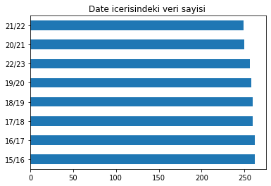

```python
df["Date"].value_counts().plot.barh().set_title("Date icerisindeki veri sayisi ");
```

Bu grafikte yıllar içindeki veri sayılarını görüyoruz.

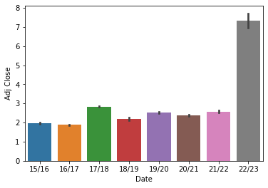

```python
import seaborn as sns

sns.barplot(x = "Date", y = "Adj Close", data= df);
```

Bu grafikte yıllar içindeki kapanış fiyatlarının ortalamasını görüyoruz.

```python
df.groupby(["Date"])["Adj Close"].mean() #burdaki veriler ile üstteki grafiği onaylamış oluyoruz.
```

```
Date
15/16    1.965482
16/17    1.880415
17/18    2.833250
18/19    2.192480
19/20    2.523526
20/21    2.363066
21/22    2.582245
22/23    7.327122
Name: Adj Close, dtype: float64
```

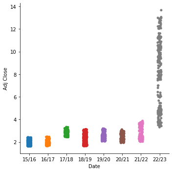

```python
sns.catplot(x = "Date", y = "Adj Close", data = df);
```

Burdaki grafikte ise yine yıllara göre hissenin aldığı en yüksek ve en düşük fiyatlar arasında gidip geldiğini görüyoruz.

```python
MinDeger=df.groupby("Date")[["Adj Close"]].min()
MaxDeger=df.groupby("Date")[["Adj Close"]].max()

df3=pd.merge(MinDeger,MaxDeger, on = "Date")
print(df3)
```

```
       Adj Close_x  Adj Close_y
Date
15/16     1.604448     2.422798
16/17     1.633940     2.464494
17/18     2.425683     3.319865
18/19     1.622302     3.126004
19/20     2.052106     3.189825
20/21     1.917265     3.105549
21/22     2.026823     3.864725
22/23     3.304556    13.670000
```

Bu sonuçlar üstteki grafiği onaylamış oluyor.Burda x olan min fiyat, y ise max fiyat oluyor.Örneğin 15/16 yılı için

Hissenin aldığı min deger 1.604448 ,max deger 2.422798 ve bu ustteki grafikte 15/16 yılı için bu aralıklarda gösteriliyor.

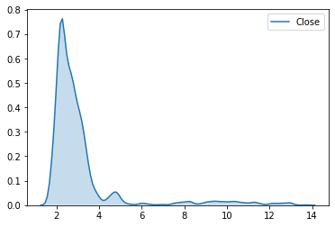

```python
sns.kdeplot(df.Close, shade = True);
```

Bu grafik Hissenin fiyatının 2015 den 2023 e kadar olan surecte en cok hangi fiyat aralıklarında yoğun olarak durduğunu gösteriyor.Gerçektende hisse 2015 den 2022 ye kadar 2 veya 3 lira seviyelerindeyken 2022/23 yılı arasında ani yükselişle 13 lira seviyelerine gelmiş.

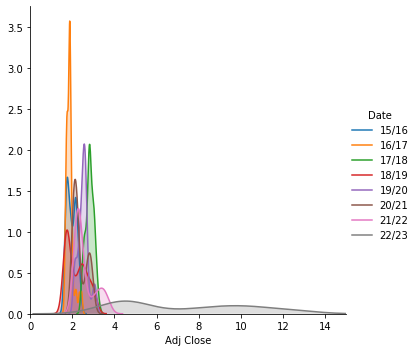

```python
#Grafik üzerinde eklenen boyutları bölerek görüntülemek için kullanılır.
#ustte belirttigimiz grafigi map'leyerek facegrid'e uyguladik
#boylece her bir Date degeri icin ayni yogunluk fonksiyonunu gözlemlemis olacagiz
(sns
 .FacetGrid(df,
              hue = "Date",
              height = 5,
              xlim = (0, 15))
 .map(sns.kdeplot, "Adj Close", shade= True)
 .add_legend()
);
```

Bu grafikten 2022-2023 yilindan onceki yillarda hissenin fiyatinin yogun olarak daha cok 2 ile 4 lira arasinda oldugunu goruyoruz.Hissenin fiyati 2022-2023 yillari arasinda hizli bir artis gostererek ilerledigini goruyoruz.

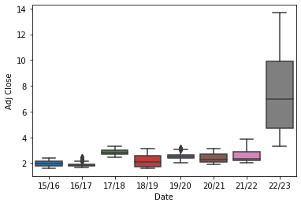

```python
#Hangi Yillarda Hisse fiyati  daha fazla artmis?
sns.boxplot(x = "Date", y = "Adj Close", data = df);
# 2022-2023 yillari arasi hissenin fiyati diger yillara gore daha fazla artmis.
```

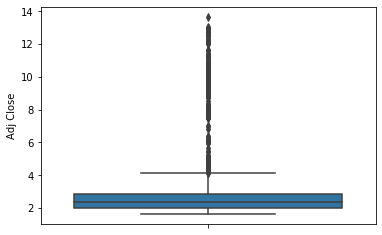

```python
sns.boxplot(y = "Adj Close",  data = df);
```

en altan yukari dogru cizgiler; minimum değer %25 %50 (median) (mavi kutunun icindeki cizgi) %75 maksimum

maksimum değere doğru giden noktalar aykırı değerleri ifade eder.Bu hissenin fiyatinin bir anda yukselmeye basladigini gosteriyor.

```python
kapanis = df["Adj Close"]
```

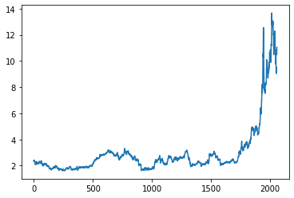

```python
kapanis.plot();
```

Burdada hissenin 2015 den 2023 yılına kadar olan surecteki fiyat değişimlerini gösteriyor.

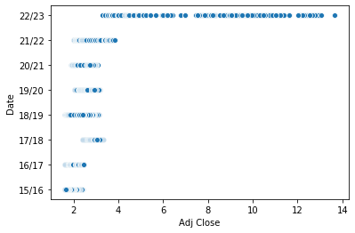

```python
#Yillara gore Fiyattaki degisim
sns.scatterplot(x = "Adj Close", y = "Date", data = df);
```

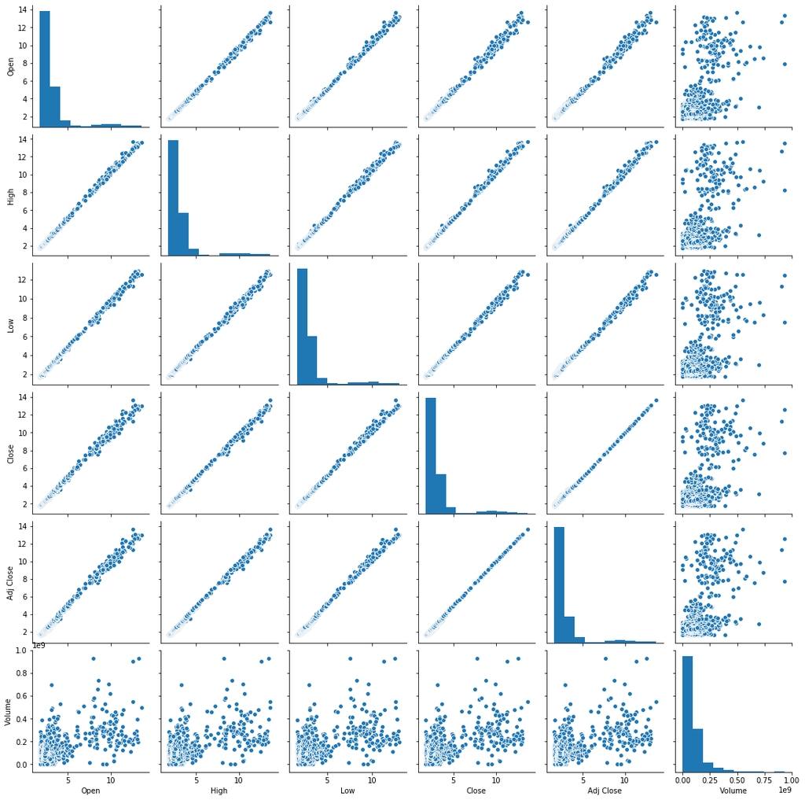

```python
#solda satır isimleri altta sutun isimlerinin çaprazlanma sonuçları

sns.pairplot(df);
```

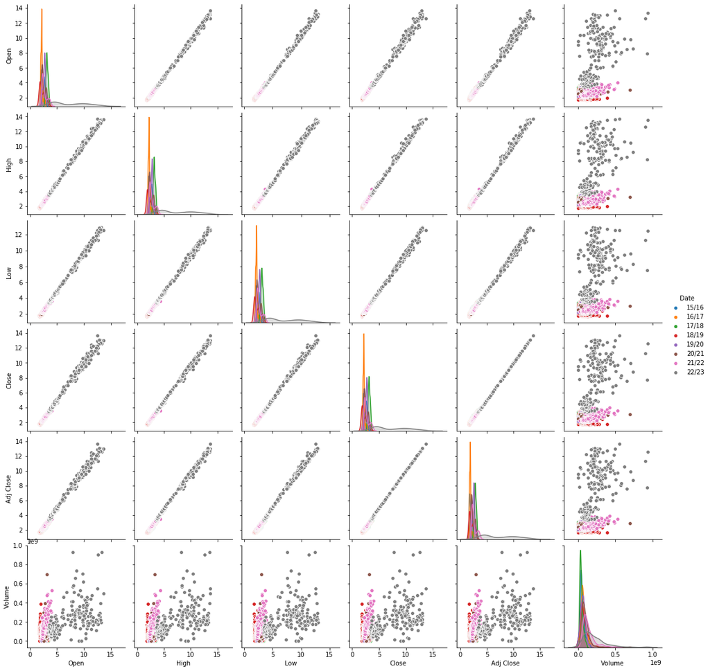

```python
#date bilgisini de grafiğe ekleyelim
sns.pairplot(df, hue = "Date");
```

```python
import numpy as np

df[0:10]
# burda veri setinin ilk 10 degerını lısteledık.
```

|  | Date | Open | High | Low | Close | Adj Close | Volume |
| --- | --- | --- | --- | --- | --- | --- | --- |
| 0 | 15/16 | 2.970060 | 2.997060 | 2.902558 | 2.902558 | 2.349932 | 55057948.0 |
| 1 | 15/16 | 2.920559 | 2.979060 | 2.916059 | 2.956560 | 2.393652 | 31801480.0 |
| 2 | 15/16 | 3.006061 | 3.006061 | 2.965560 | 2.992560 | 2.422798 | 37002206.0 |
| 3 | 15/16 | 2.988060 | 2.988060 | 2.929559 | 2.938559 | 2.379078 | 30158007.0 |
| 4 | 15/16 | 2.866558 | 2.889058 | 2.857558 | 2.875558 | 2.328072 | 83954148.0 |
| 5 | 15/16 | 2.898058 | 2.916059 | 2.875558 | 2.911559 | 2.357219 | 79967589.0 |
| 6 | 15/16 | 2.992560 | 2.997060 | 2.934059 | 2.943059 | 2.382722 | 37755186.0 |
| 7 | 15/16 | 2.974560 | 2.983560 | 2.916059 | 2.916059 | 2.360862 | 43176303.0 |
| 8 | 15/16 | 2.826057 | 2.862058 | 2.808057 | 2.830557 | 2.291639 | 79117913.0 |
| 9 | 15/16 | 2.853057 | 2.862058 | 2.830557 | 2.853057 | 2.309855 | 33613775.0 |

```python
#orneklem cekimi
np.random.seed(150) #rastgelelilik islemini her yeniden cagirildiginda ayni sayilari uretmesi icin şartlar
orneklem = np.random.choice(a = df["Adj Close"], size = 100) #verıden rasgele deger aldık.
orneklem[0:10] # aldıgımız ılk 10 degerı gosterdık.
```

```
array([ 2.616751,  2.244277,  1.987119,  4.61    ,  2.50298 ,  2.384994,
       12.55    ,  2.612537,  3.239421,  2.102671])
```

```python
orneklem.mean() # Kapanis fiyatlari icerisinden rastgele aldigim 10 degerin ortalaması
```

```
3.0153857199999994
```

```python
df["Adj Close"].mean() #hisse kapanis fiyatlarinin ortalaması
```

```
2.951141045719849
```

```python
np.random.seed(10)
orneklemList=[]
for i in range(10):
    orneklemList.append(np.random.choice(a = df["Adj Close"], size = 100))
```

```python
orneklemList=np.array(orneklemList)
orneklemList.mean()     #daha fazla veri icinden ortalama
```

```
3.0400170740000005
```

Burda daha fazla veri almama rağmen Kapanıs fiyatlarının ortalamasından uzaklaşmış olduk.Bunun nedeni Veri setimizde aykırı değerler(hisse 2-4 lira arasında yogun olarak kaldıktan sonra 13 lıralara çıkması) olması.

```python
!pip install researchpy
import researchpy as rp
```

```
Keyring is skipped due to an exception: 'keyring.backends'
```

```python
#surekli (sayısal) değişkenler için kullanılır.
rp.summary_cont(df[["Adj Close"]])
```

|  | Variable | N | Mean | SD | SE | 95% Conf. | Interval |
| --- | --- | --- | --- | --- | --- | --- | --- |
| 0 | Adj Close | 2056.0 | 2.9511 | 2.0049 | 0.0442 | 2.8644 | 3.0379 |

N: eleman sayısı Mean: ortalama SD: Standart Deviation (Standart sapma) SE: Standart Error (Standart Hata) 95% Conf. interval :(default değeri 95%) %95 güven aralığı, popülasyonun gerçek ortalamasını içerdiğinden %95 emin olabileceğiniz bir değerler aralığıdır. Doğal örnekleme değişkenliği nedeniyle, örnek ortalaması (CI'nin merkezi) örnekten örneğe değişecektir.Güven Aralığı: Anakütle parametresinin tahmini değerini kapsayabilecek iki sayıdan oluşan bir aralık bulunmasıdır.yukarıdaki örnek için; Adj Close

n=2056 mean=2.9511  
sd=2.0049

güven aralığın ne olacak? (bizim ornegimiz icin 95%) Z Tablo değeri 95% için 1,96

```python
a=(1.96*(2.0049/pow(2056,1/2)))
a
b=2.9511-a
c=2.9511+a
print(b)
print(c)
```

```
2.8644362989472327
3.037763701052767
```

bu aralıklarda alınması gerektiğini gösteriyor.

```python
df[["Low","Adj Close"]].cov() #Kovaryans, rassal iki değişken arasındaki doğrusal ilişki ölçülerinden biridir. Kovaryans değeri ile iki değişkenin birlikte ne kadar değiştikleri ve aralarındaki ilişkinin yönü hakkında fikir sahibi oluruz.
```

|  | Low | Adj Close |
| --- | --- | --- |
| Low | 3.543689 | 3.763855 |
| Adj Close | 3.763855 | 4.019588 |

```python
df[["Low","Adj Close"]].corr()
```

|  | Low | Adj Close |
| --- | --- | --- |
| Low | 1.000000 | 0.997274 |
| Adj Close | 0.997274 | 1.000000 |

# Eksik Değerin Silinmesi

```python
df = df.dropna(subset=["Low"]) # eksik olan veiyi sildik
```

```python
df.tail()
```

|  | Date | Open | High | Low | Close | Adj Close | Volume |
| --- | --- | --- | --- | --- | --- | --- | --- |
| 2051 | 22/23 | 9.04 | 9.04 | 9.04 | 9.04 | 9.04 | 0.0 |
| 2052 | 22/23 | 9.52 | 9.52 | 9.52 | 9.52 | 9.52 | 0.0 |
| 2053 | 22/23 | 9.52 | 9.52 | 9.52 | 9.52 | 9.52 | 0.0 |
| 2055 | 22/23 | 10.38 | 10.47 | 10.06 | 10.47 | 10.47 | 27672377.0 |
| 2056 | 22/23 | 11.42 | 11.42 | 10.76 | 11.05 | 11.05 | 123223286.0 |

# Makine Öğrenmesi Ve Tahmin Yapma

```python
import pandas as pd
from sklearn.preprocessing import MinMaxScaler
from sklearn.model_selection import train_test_split
from keras.models import Sequential
from keras.layers import LSTM, Dense

# Veri kümesini yükleme
data = df

# Veri ön işleme
scaler = MinMaxScaler(feature_range=(0, 1))
scaled_data = scaler.fit_transform(data['Close'].values.reshape(-1, 1))

# Eğitim ve test veri setlerini oluşturma
train_size = int(len(scaled_data) * 0.8)
train_data = scaled_data[:train_size]
test_data = scaled_data[train_size:]

# X ve y veri setlerini oluşturma
def create_dataset(data, lookback):
    X, y = [], []
    for i in range(len(data) - lookback - 1):
        X.append(data[i:(i + lookback), 0])
        y.append(data[i + lookback, 0])
    return np.array(X), np.array(y)

lookback = 30  # Önceki 30 günü kullanarak tahmin yapmak için
X_train, y_train = create_dataset(train_data, lookback)
X_test, y_test = create_dataset(test_data, lookback)

# Model oluşturma
model = Sequential()
model.add(LSTM(units=50, return_sequences=True, input_shape=(X_train.shape[1], 1)))
model.add(LSTM(units=50))
model.add(Dense(units=1))

# Modeli derleme
model.compile(optimizer='adam', loss='mean_squared_error')

# Modeli eğitme
model.fit(X_train, y_train, epochs=100, batch_size=32)

# Gelecekteki fiyatları tahmin etme
last_30_days = scaled_data[-lookback:]
X = np.array(last_30_days).reshape(1, lookback, 1)
predicted_price = model.predict(X)
predicted_price = scaler.inverse_transform(predicted_price)

print("Gelecekteki tahmin edilen fiyat:", predicted_price)
```

```
Gelecekteki tahmin edilen fiyat: [[11.166001]]
```